# Concepts Analysis

Kyra Wilson

2020-01-11

##Data gathering

We begin by getting utterances from childes-db. The default option is returning all non-child English utterances spoken to children 3 years of age or youger

Retrieve number of individual children and transcripts used in analysis

```
## [1] "Number of children:" "1046"
```

```
## [1] "Number of transcripts:" "8654"
```

```
## [1] "Ratio of Explicit Categorization to Category Occurrences for Age <  3"
## [1] "Ratio of Explicit Categorization to Category Occurrences for Age <  4"
## [1] "Ratio of Explicit Categorization to Category Occurrences for Age <  5"
## [1] "Ratio of Explicit Categorization to Category Occurrences for Age <  6"
```

##Explicit co-occurrences

To get co-occurrences of categories, run explicit_cues.py with files adult_utterances3.csv and wb_nouns_edited.csv.

##Helper functions

Given word vectors from w2v and list of words, return cosine similarity of all word pairs.

Given word vectors from explicit co-occurrence, return cosine similarity of all word pairs.

Given cosine similarity and a distance matrix, return the optimal number of clusters for the data based on median of 3 cluster measures (kl, gap, silhouette).

Given cosine similarities, return a clustering of the words.

Given cosine similarities and mapping of instances and their categories, calculate the densities of similarities within an between clusters.

Given a dataframe with within- and between-category densities, plot the densities

Given a ataframe with within- and between-category densities and list of instances, calculate the AUC for each category

Given cosine similarities and a list of instances, replicate Bornstein and Arterberry 2010 experiment.

Given cosine similarities and a list of instances, replicate Bornstein and Arterberry 2010 experiment with random probabilities as a control.

Given AUC measures for w2v, random, and optional explicit cues, plot the results of the experiments.

##Main functions

First, get list of categories and instances and reorganize them so they can be used in later functions.

Get cosine similarity (density plot), AUC, development up to 6, and 2-dimensional plot for w2v, explicit verb co-occurrence, and general co-occurrence

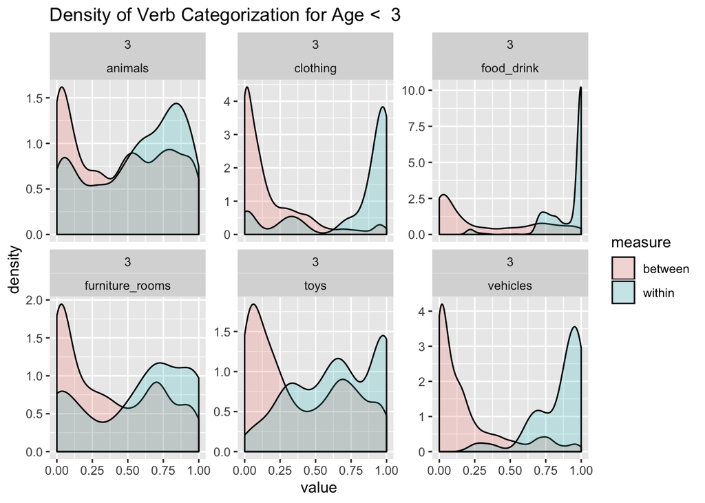

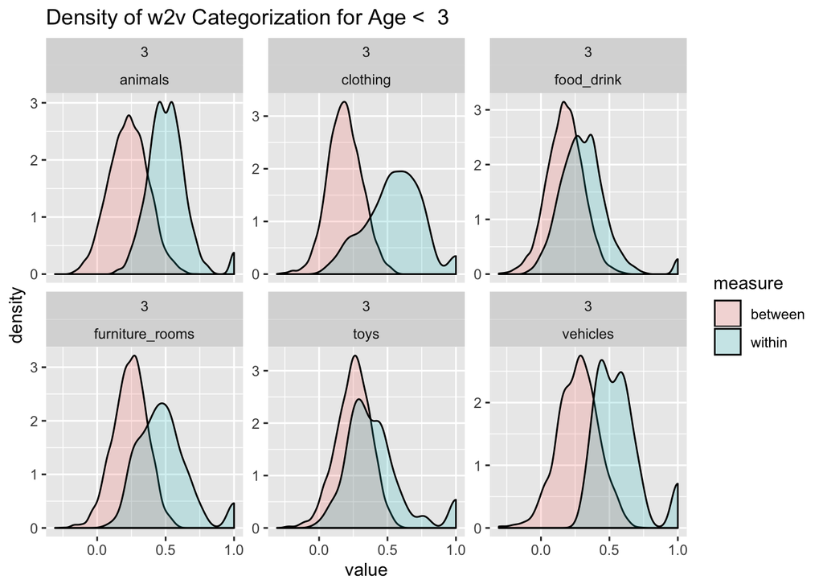

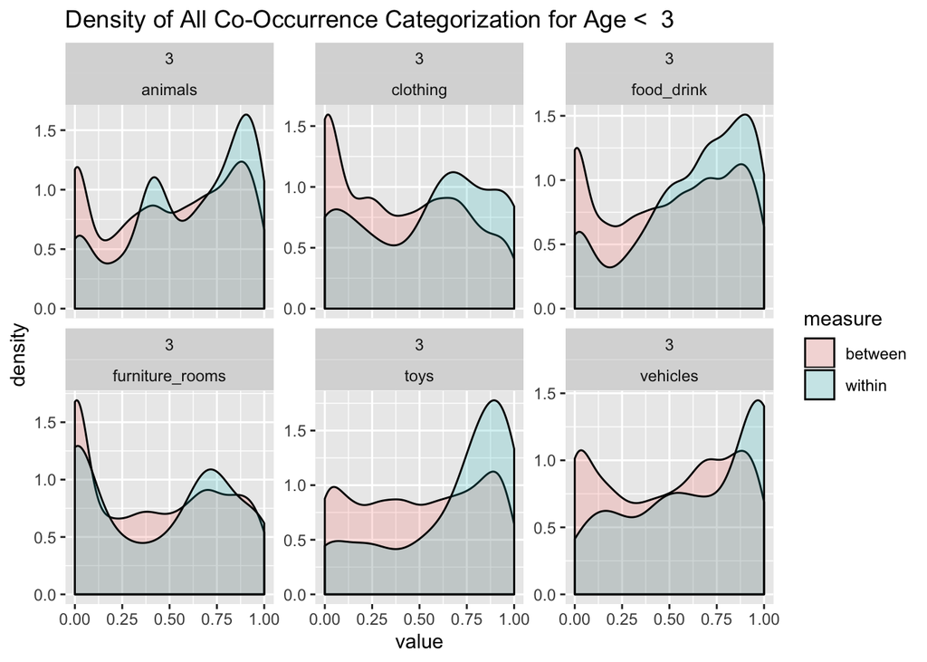

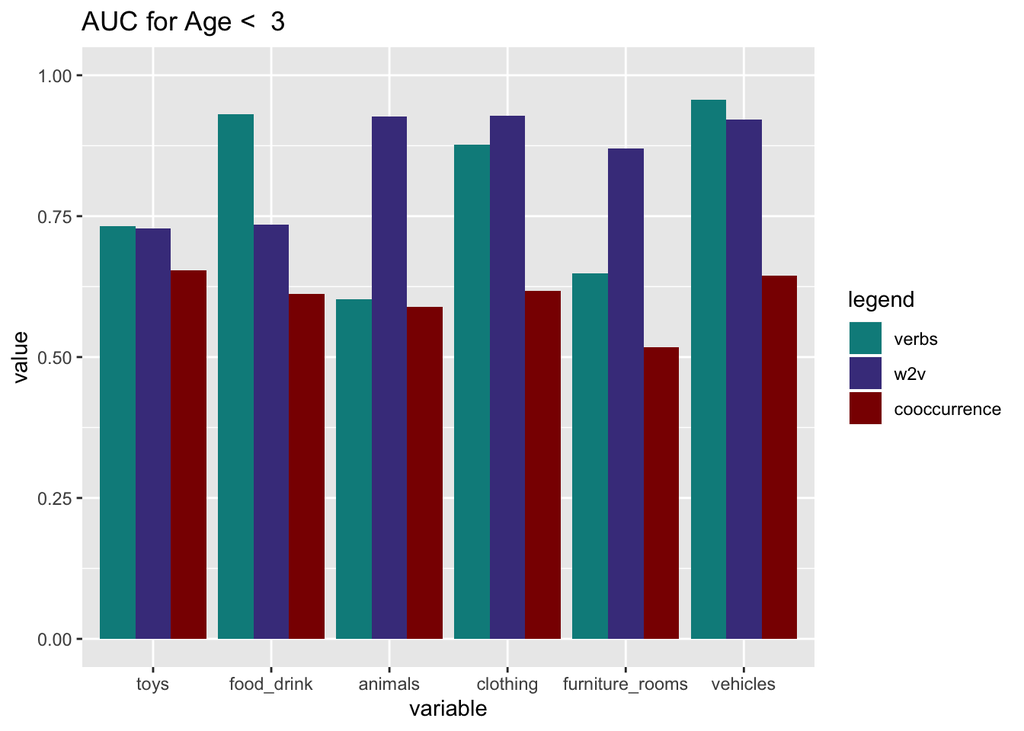

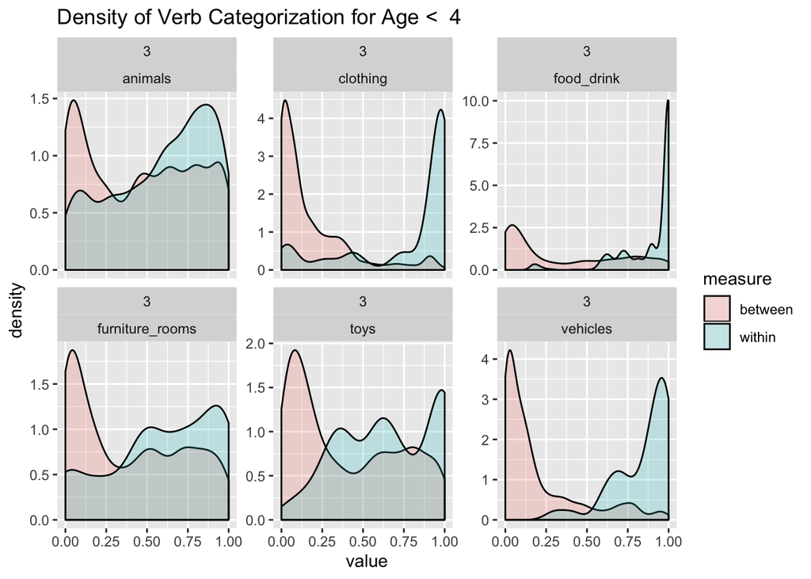

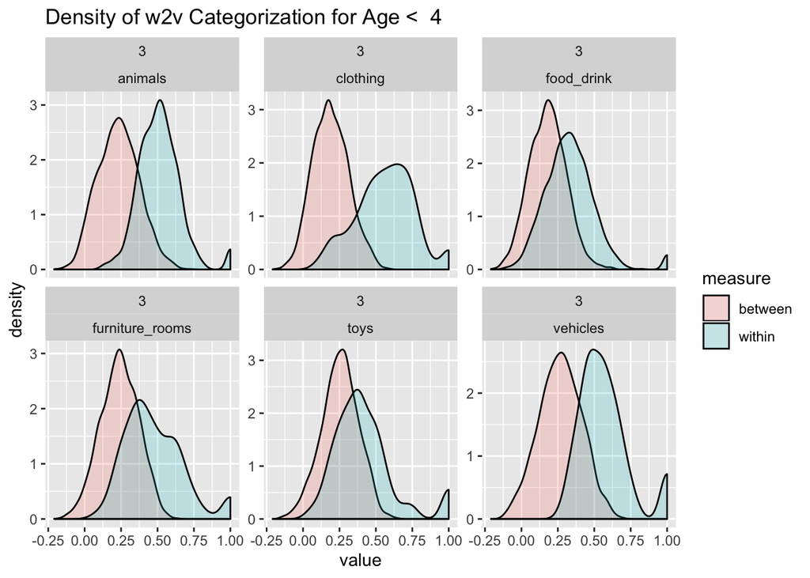

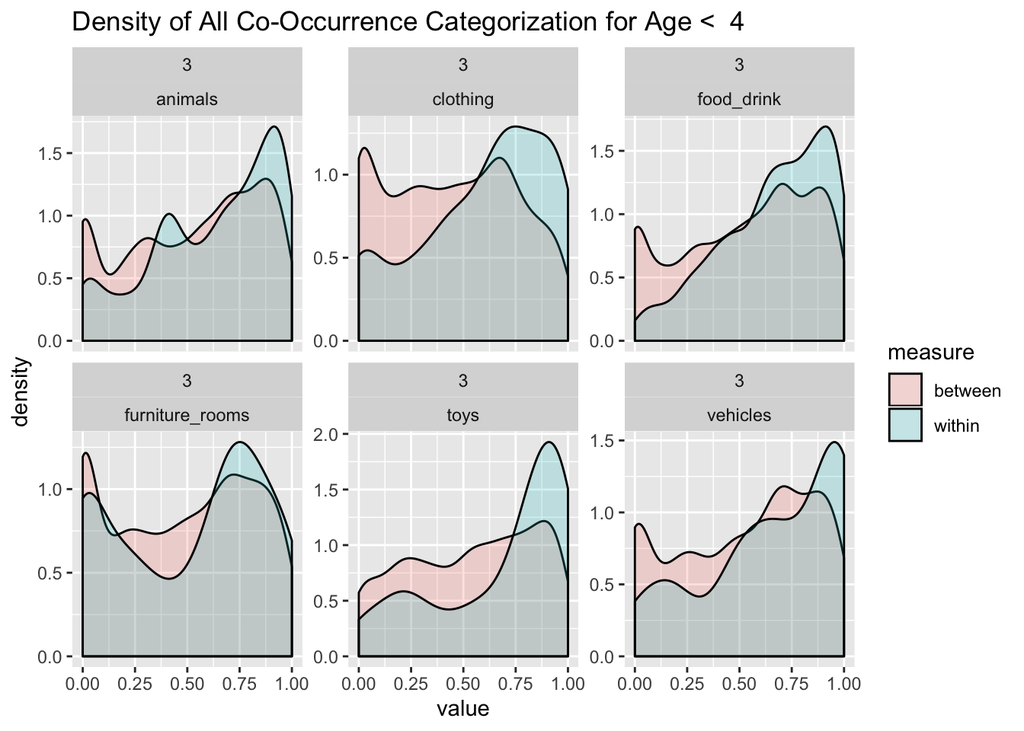

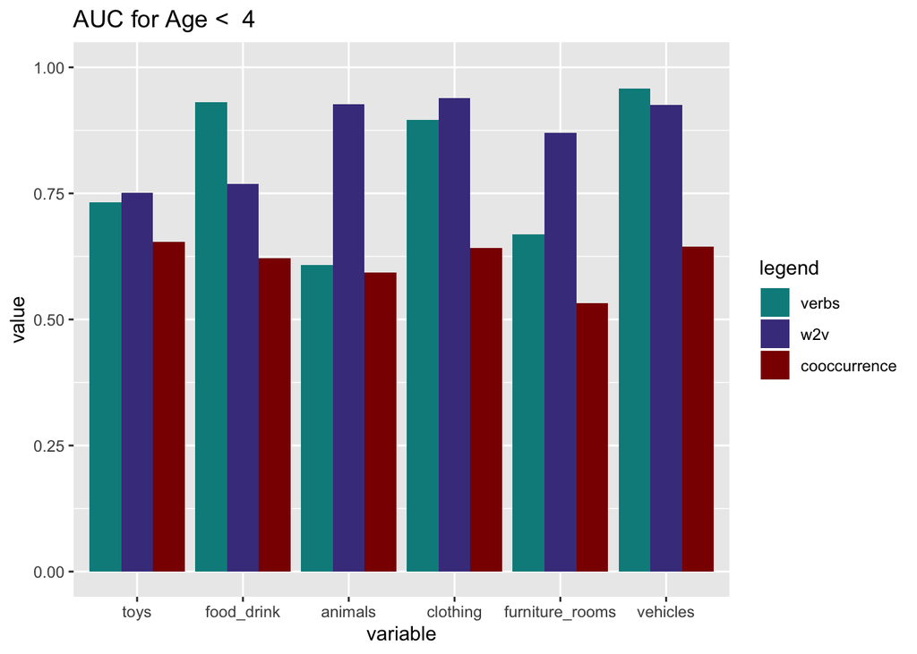

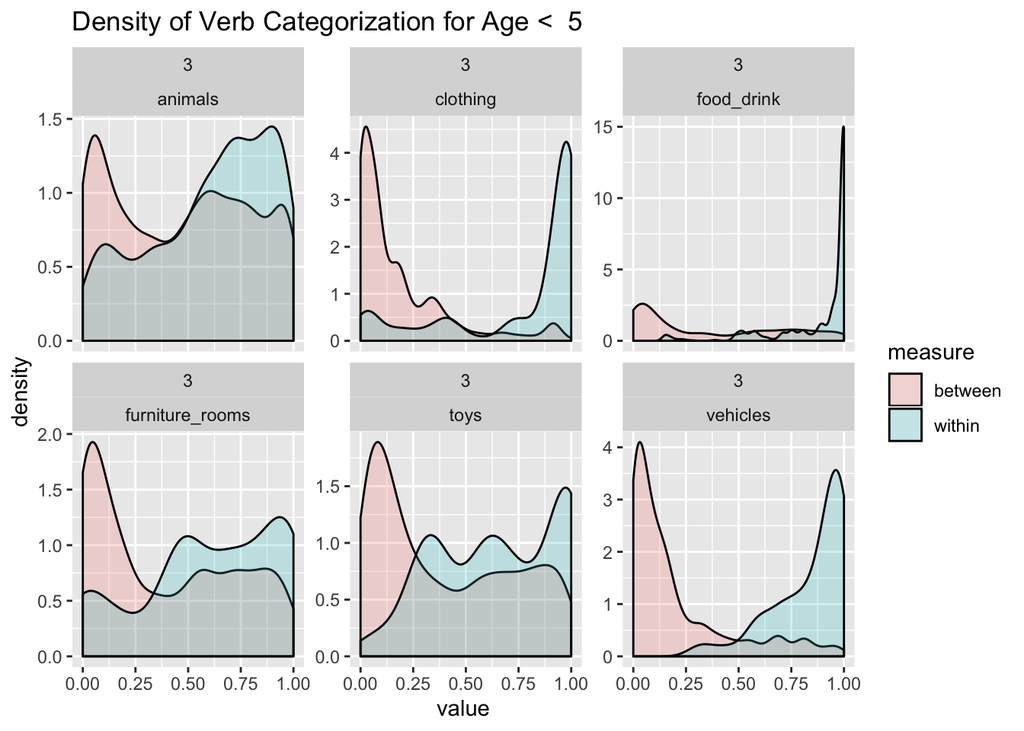

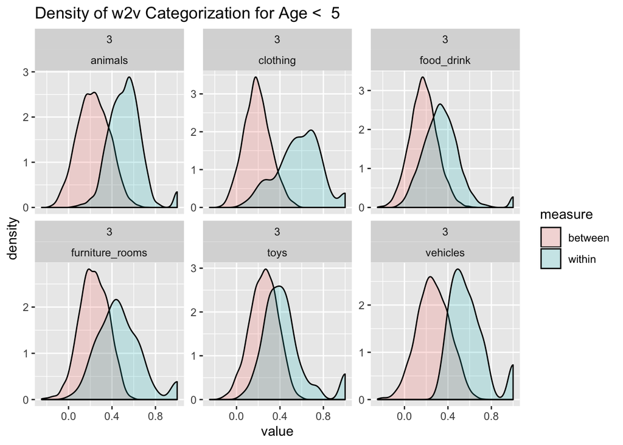

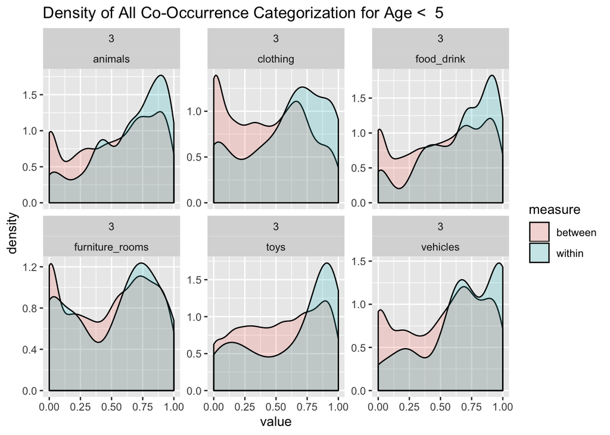

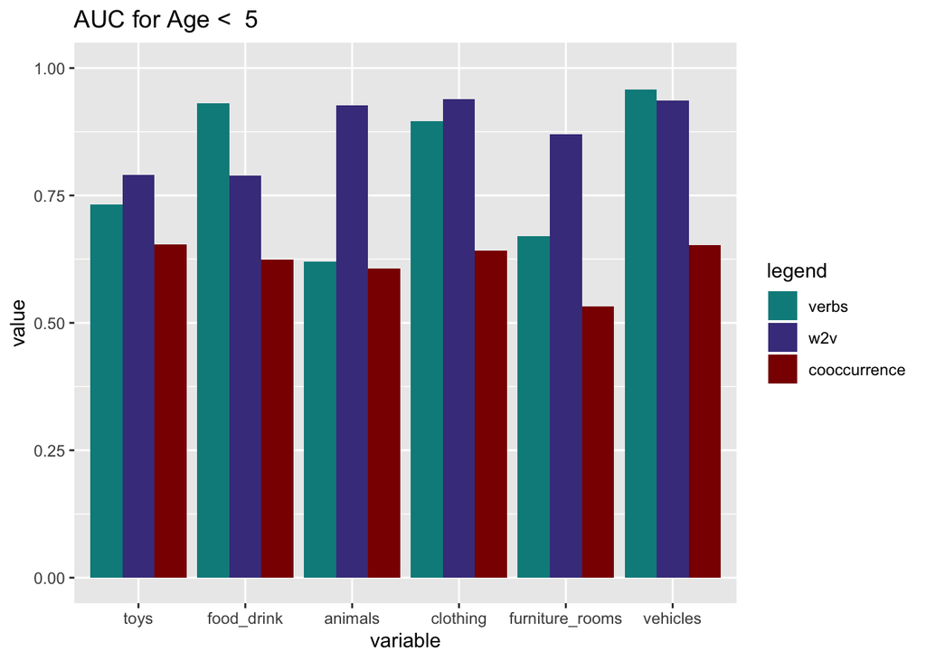

[5 more figures not shown]

Get the cosine similarities for both w2v and explicit cues. (Can be read from file or recalculated.)

Get the within- and between- similarity densities for each category.

Using within- and between- similarities, calculate AUC for each of the categories.

Calculate cosine similarity, within- and between- similarities, and AUC for explicit cues with only category co-occurrence and not verb co-occurrence.

Visualize explicit and w2v clusters from cosine similarities

Calculate cosine similarity, within- and between- similarities, and AUC for different ages of children (right now does 3-6).

Replicate experiment from Bornstein and Arteberry 2010 for explicit categories with verb and category co-occurrence and w2v co-occurrence.

Construct “animals” and “artifacts” categories. Calculate cosine similarity, within- and between- similarities, and AUC for w2v categorization of these categories.

Replicate experiment from Bornstein and Arteberry 2010 for “animal” and “artifacts” categories.